# Use your font

Junsok Huhh

2017-11-16

# Non-alphabetical

폰트 문제는 쉬운 듯 어려운 문제다. 그냥 OS에서 폰트 깔아서 쓰듯 쓸 수 있으면 좋으련만 ‘그렇게’ 쉽게 쓸 수는 없다. R에서 그래프를 그려본 사람이라면, 어 “왜 (그래프에서) 폰트가 네모박스로 나와”하는 상황을 한번은 마주쳐 봤을 것이다. 이는 R과 RStudio가 OS에서 끌어다 쓰는 부분이 제한적이기 때문에 생기는 일이다. 그렇다고 못생긴 굴림체와 계속 살 수는 없는 노릇이니 방법을 찾긴 해야 한다.

# extrafont? showtext!

언제나 그렇듯이 구글 검색을 해보면 extrafont 패키지가 주로 검색된다.[^1] 이 패키지는 로컬 머신에 설치된 폰트를 끌어다가 그림에 심는 것을 구현한다. 다만 이 경우 로컬 머신을 오가며 작업할 경우 폰트 사용을 일관되게 하기 곤란해질 수 있다. 아울러 패키지가 트루타입(ttf)만 지원하기 때문에 폰트 이용 자체에도 다소 한계가 있다.

Yixuan Qiu가 개발한 showtext는 보다 일관된 폰트 사용을 목표로 한다. 우선 이 패키지를 쓰면 폰트를 꼭 시스템에 미리 설치해 둘 필요가 없다. 설치되지 않은 폰트도 파일의 경로만 지정해주면 그래프 등의 시각 결과물에서 해당 폰트를 잘 구현해준다. 아울러 TrueType, OpenType, Type 1, web font 등 다양한 포맷을 지원한다. 구글에서 제공하는 폰트의 경우에는 파일 경로로 필요 없다. 이름만 지정해주면 온라인에서 다운로드 받아서 알아서 구현한다. 물론 구글 폰트 데이터베이스에 등재된 한글 폰트가 없다는 것이 살짝 아쉬운 대목이다.

# Basic

```r
#### Start of testing code
library(tidyverse)
library(showtext)
```

[구글](https://fonts.google.com/)에 등록된 폰트는 쉽게 불러올 수 있다.

```r
font_add_google("Gochi Hand", "gochi")
font_add_google("Schoolbell", "bell")
```

이렇게 호출하면 구글 리포지터리에서 폰트를 불러와 설정한다. 1번 인자가 구글의 fullname이고 2번 인자가 내가 코드에서 호출할 이름이다.

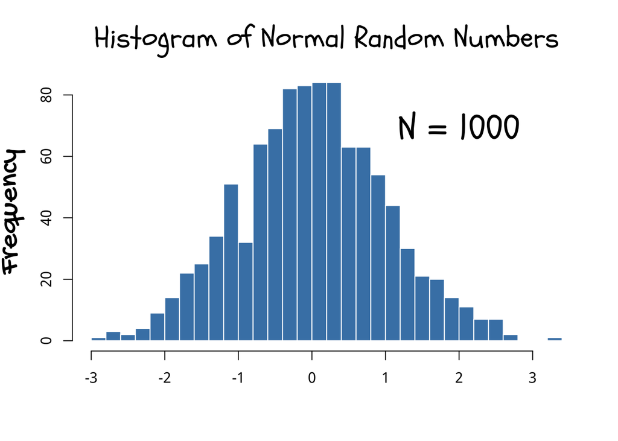

```r
showtext_auto()

#windows() # if your local os is Windows
# x11() # if your local os is Macos

set.seed(123)
hist(rnorm(1000), breaks = 30, col = "steelblue", border = "white",
     main = "", xlab = "", ylab = "")
title("Histogram of Normal Random Numbers", family = "bell", cex.main = 2)
title(ylab = "Frequency", family = "gochi", cex.lab = 2)
text(2, 70, "N = 1000", family = "bell", cex = 2.5)
```

안타깝지만 RStudio의 기본 그래픽 장치는 showtext와 호환되지 않는다. 즉, RStudio 화면 우측 하단에는 폰트가 위의 그림처럼 표현되지 않는다. 당황하지 말자. 그냥 명령어로 별도의 그래픽 장치를 호출하면 된다. Windows라면 `windows()`를, Macos라면 `x11()`을 적절한 위치에 넣어주자. 이 문서가 작성된 rmarkdown에서도 폰트가 제대로 표현되지 않는다. 이때 코드 옵션에 `fig.showtext=TRUE`를 추가하면 위의 그림처럼 잘 나온다. 즉, 마크다운 코드 옵션의 윗단을 아래와 같이 적절하게 처리해주면 되겠다.

```
{R message=FALSE, warning=FALSE, fig.showtext=TRUE}
```

그림 출력 상태를 온오프 하기 위해서는 `showtext_auto()`로 자동화할 수도 있고, `showtext_begin()`, `showtext_end()`로 미세조정을 추구할 수도 있다.[^2]

# What about Korean font?

앞서도 이야기 했지만 Google fonts에는 안타깝게도 한글이 없다. early access에는 10종 정도가 포함되어 있지만 정식 리포지터리에는 없으므로 `font_add_google()`로는 한글을 구현할 수 없다. 이 경우 적절한 위치에 폰트 원본 파일을 놓고 이를 불러오면 된다.

```r
font_add(family = "hwhitecat", regular = "fonts/HoonWhitecatR.ttf")
```

위의 코드는 현재 디렉토리의 하위에 위치한 `fonts/HoonWhitecatR.ttf` 폰트를 “hwitecat”이라는 패밀리의 레귤러로 심어준다. 레귤러, 이탤릭, 볼드 등을 따로 따로 지정할 수도 있다.

```r
font_add("constan", regular = "fonts/constan.ttf", italic = "fonts/constani.ttf")
```

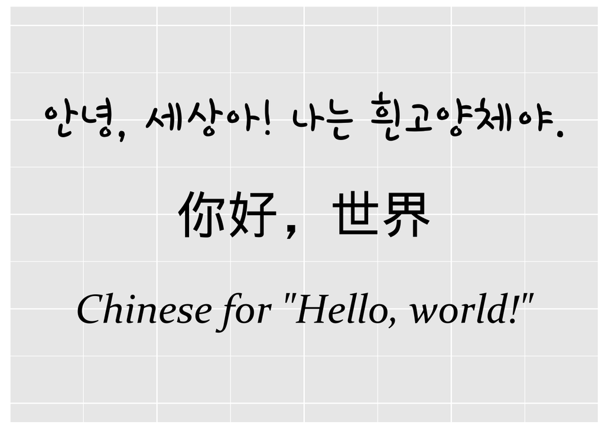

```r
showtext_auto()

p = ggplot(NULL, aes(x = 1, y = 1)) + ylim(0.8, 1.2) +
  theme(axis.title = element_blank(), axis.ticks = element_blank(),
        axis.text = element_blank()) +
  annotate("text", 1, 1.1, family = "hwhitecat", size = 17,
           label = "안녕, 세상아! 나는 흰고양체야.") +
  annotate("text", 1, 1, family = "heiti", size = 15,
           label = "\u4F60\u597D\uFF0C\u4E16\u754C") +
  annotate("text", 1, 0.9, label = 'Chinese for "Hello, world!"',
           family = "constan", fontface = "italic", size = 12)

print(p)
```

언제나 그렇지만 너무 많은 서체를 쓰는 것은 (단연코!) 보기 좋지 않다. 단정하게 그냥 나눔고딕 혹은 Noto Sans CJK KR 정도로 만족하면 어떨까?

# Digression

## How to generate and save graphs

혹시나 하는 마음에서 부록 하나 덧붙여 본다. R도 그렇지만 대개의 오픈소스 소프트웨어들은 그림을 만들 때 “장치”를 사용해서 만든다. 그래픽을 생성해 출력하는 장치라고 보면 되고, 스크린, pdf, png 등등 여러가지 형태를 지닌다. 일반적으로 OS 상에서 화면에 있는 그림을 캡쳐해서 포맷에 맞게 저장하는 식으로 생각하지 말고, 필요한 그림은 장치를 통해 생성한다고 이해하면 쉽다.

바로 위에 예를 RStudio에 그대로 복붙했다면, 출력물 `p`에서 폰트를 제대로 볼 수 없었을 것이다. 앞서도 말했지만, RStudio의 기본 화면 장치는 showtext를 아직 지원하지 않는다. 아래 처럼 해야 제대로 출력된다.

```r
windows()  # if your local os is Windows
# x11() # if your local os is Macos
print(p)
```

여기까지 실행하면 화면에 팝업으로 출력물이 뜨게 된다. PDF로 저장하기 위해서는 PDF 장치를 부르면 된다. 이때 `dev.off()`를 지정해줘야 pdf 저장이 완료된다는 점 명심하자. 화면 팝업은 수동으로 창을 끄면 `dev.off()`가 되지만 파일은 그렇지 않다. 반드시 `dev.off()`를 넣어줘야 파일을 쓰게 된다.

```r
pdf("YOUR_FILENAME.pdf", width = 7, height = 4)
print(p)
dev.off()
```

이게 귀찮다면 ggplot2 패키지를 쓰자. ggplot2는 장치를 포맷 별로 편리하게 기록할 수 있는 통일적인 방법을 제공한다. `ggsave` 명령어를 쓰면 `dev.off()`없이 대부분의 포맷으로 아래와 같이 편리하게 저장할 수 있다.

```r
ggsave("YOUR_FILENAME.pdf", p, width = 7, height = 4)
ggsave("YOUR_FILENAME.png", p, width = 7, height = 4, dpi = 96)
```

## Font embedding

이건 문제가 될 수도 있고 아닐 수도 있다. 하지만 문제가 될 것 같으면 확실히 해두면 되겠다.

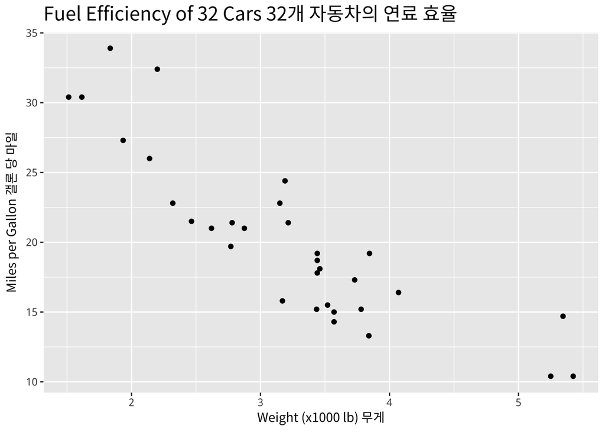

```r
#install.packages('Cairo')
library(Cairo)

font_add(family = "notosanskr", regular = "fonts/NotoSansCJKkr-Regular.otf")

q <- ggplot(mtcars, aes(x=wt, y=mpg)) + geom_point() +
  ggtitle("Fuel Efficiency of 32 Cars 32개 자동차의 연료 효율") +
  xlab("Weight (x1000 lb) 무게") + ylab("Miles per Gallon 갤론 당 마일") +
  theme(title=element_text(family="notosanskr", size = rel(1.2)),
        axis.title=element_text(family="notosanskr", size = rel(0.8)),
        strip.text=element_text(family="notosanskr", size = rel(0.8)))

print(q);
```

```r
ggsave(filename="foo.pdf", q)
```

[^1]: [여기](http://freesearch.pe.kr/archives/3138)를 참고하라.
[^2]: 자세한 것은 [여기](https://cran.rstudio.com/web/packages/showtext/vignettes/introduction.html)를 참고하라.